# Project 3 - Section 1

Team 1

March 23, 2016

## 4. Visualization and Analysis

### a. Visualization and Graphs

We used the Data Science Skills Database to create bar charts, word clouds and other visualization tools that show and summarize the group’s findings. The Transformer group provided database `views` to provide results to reduce the need for transformations in R.

```r
skilldb <- dbConnect(MySQL(), user=proj_user, password=proj_pwd, dbname=proj_db, host=proj_host)
Views <- dbGetQuery( skilldb,"SELECT TABLE_NAME 'Views'
                              FROM INFORMATION_SCHEMA.TABLES
                              WHERE table_schema = 'skill' and table_type = 'view';")
kable(Views)
```

## Views

vw_bottom10_skill_sets_overall  
vw_bottom10_skills_overall  
vw_skill_type_frequency_percent  
vw_top10_skill_sets_overall  
vw_top10_skills_by_source  
vw_top10_skills_overall  
vw_top10_skills_overall_excluding_rjmetrics vw_top3_skills_by_skill_set  
vw_top5_skill_sets_by_skill_type

The Transformer team provided the skill names using two different methods. One involved a `scalar rating` that normalizes skill names across the entire database and the other used a `weighted rating` that weighted the ratings within their respective groups.

```r
Top3_by_source <- dbGetQuery( skilldb, sprintf("SELECT * FROM %s", Views[5,]))

Top3_by_source <- Top3_by_source %>%
                  arrange(source_name, desc(rating_scalar)) %>%
                  group_by(`source_name`) %>%
                  top_n(n = 3, wt = rating_scalar) %>%
                  select(source_name, skill_name, rating_scalar)

kable(Top3_by_source)
```

| source_name | skill_name | rating_scalar |
| --- | --- | --- |
| Google | big data | 100 |
| Google | machine learning | 32 |
| Google | Hadoop | 25 |
| Indeed | GIS | 100 |
| Indeed | statistical graphics | 79 |
| Indeed | XML | 79 |
| Kaggle | Python | 100 |
| Kaggle | analytics | 81 |
| Kaggle | machine learning | 67 |
| RJMETRICS | analysis | 100 |
| RJMETRICS | R | 79 |
| RJMETRICS | Python | 74 |

Unsuprisingly, we see that technicial skills appear at the top of the lists for each of our data sources but not the exact same type.

Let’s look at the top 5 skills sets by skill type by pulling down the view from the database at vw_top5_skill_sets_by_skill_type and checking the results.

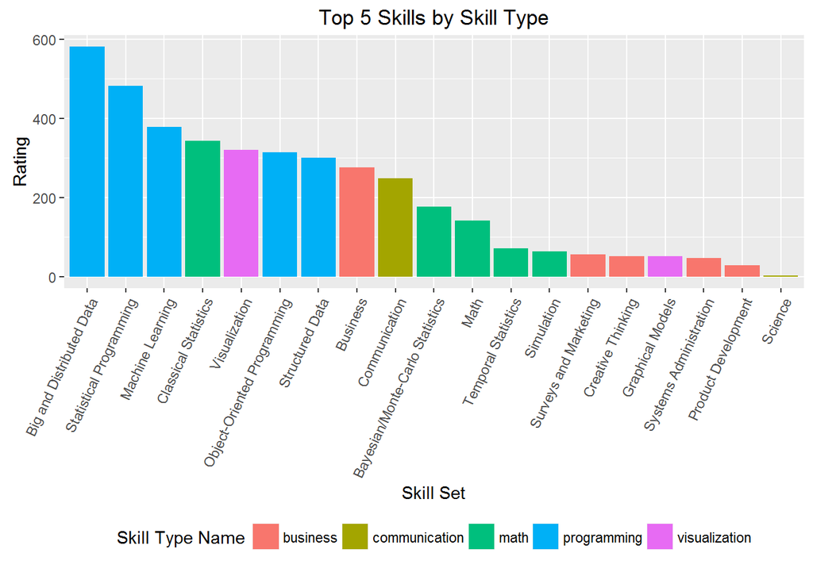

```r
scalar_skills <- dbGetQuery(skilldb, sprintf("Select * from %s", Views[9,]))

scalar_skills <- scalar_skills %>%
                   select(skill_type_name, rating_scalar, skill_set_name) %>%
                   arrange(skill_set_name)

ggplot(scalar_skills, aes(y = rating_scalar,
                          x = reorder(skill_set_name, -rating_scalar),  fill = skill_type_name)) +
      geom_bar(stat = "identity")  +
      scale_fill_discrete(name="Skill Type Name") +
      xlab("Skill Set") +
      ylab("Rating") +
      theme(legend.position = "bottom",
            axis.text.x = element_text(angle = 65, hjust = 1)) +
      ggtitle("Top 5 Skills by Skill Type")
```

We continue to see techinical skills being the most often found skills in each source. `Big and Distributed Data` is the top skill amoung skill types which seems appropriate for data science.

#### 2. Horizontal Bar Graph Showing the Top 20 Data Science Skills from the 3 Sources (Google, Indeed and Kaggle)

Comparing the top lists of each data source will be useful in understanding some similarities or dissimalities between the sources

order by source_name (asc) and weighted_rating_overall

```r
jobdata <- dbGetQuery(skilldb, "select * from tbl_data")
newjobdata <- jobdata[with(jobdata, order(source_name,-weighted_rating_overall)),]
```

list skill_name for each source_name

```r
Google <- subset(newjobdata, source_name == "Google", select=c(source_name, skill_name,weighted_rating_overall))
Google <- Google[c(1:20),]
Indeed <- subset(newjobdata, source_name == "Indeed", select=c(source_name, skill_name, weighted_rating_overall))
Indeed <- Indeed[c(1:20),]
Kaggle <- subset(newjobdata, source_name == "Kaggle", select=c(source_name, skill_name, weighted_rating_overall))
Kaggle <- Kaggle[c(1:20),]
Combined <- cbind(Google,Indeed,Kaggle)
Combined$source_name <- NULL
Combined$source_name <- NULL
Combined$source_name <- NULL
colnames(Combined)[1] <- "GoogleSkills"
colnames(Combined)[2] <- "GoogleRatings"
colnames(Combined)[3] <- "IndeedSkills"
colnames(Combined)[4] <- "IndeedRatings"
colnames(Combined)[5] <- "KaggleSkills"
colnames(Combined)[6] <- "KaggleRatings"
kable(Combined)
```

|  | GoogleSkills | GoogleRatings | IndeedSkills | IndeedRatings | KaggleSkills | KaggleRatings |
| --- | --- | --- | --- | --- | --- | --- |
| 67 | big data | 21.12880 | GIS | 29.3037 | Python | 14.085900 |
| 91 | machine learning | 7.54601 | XML | 23.2669 | machine learning | 9.558280 |
| 78 | Hadoop | 6.03681 | text mining | 21.8834 | programming | 7.042940 |
| 72 | data natives | 4.02454 | clustering | 20.7515 | SQL | 6.036810 |
| 126 | R | 3.52147 | BUGS | 20.1227 | modeling | 4.527610 |
| 145 | Python | 3.52147 | Pig | 19.4939 | big data | 3.521470 |
| 102 | SQL | 3.01840 | JSON | 18.3620 | Java | 3.018400 |
| 113 | NOSQL | 2.51534 | SVM | 18.1104 | Hadoop | 3.018400 |
| 69 | data engineering | 2.01227 | DBA | 17.9847 | analytics | 2.963190 |
| 71 | data mining | 1.50920 | ANOVA | 17.3558 | business | 1.717790 |
| 39 | analytics | 1.41718 | Simulation | 17.1043 | statistics | 1.674850 |
| 3 | analysis | 1.22699 | Rails | 16.6012 | predictive analytics | 1.509200 |
| 14 | information | 1.10429 | Objective C | 16.2239 | SAS | 1.509200 |
| 59 | Java | 1.00613 | Teradata | 15.9724 | MATLAB | 1.509200 |
| 63 | Ruby | 1.00613 | PostgreSQL | 15.5951 | team | 0.773006 |
| 74 | fintech | 1.00613 | SPSS | 15.3436 | communication | 0.607362 |
| 86 | tableau | 1.00613 | Oracle | 15.2178 | R | 0.503067 |
| 87 | web development | 1.00613 | MySQL | 14.3374 | interpersonal | 0.496933 |
| 97 | galaxql | 1.00613 | MATLAB | 13.5828 | management | 0.496933 |
| 99 | RSS | 1.00613 | Stata | 13.4571 | research | 0.490798 |

plot results

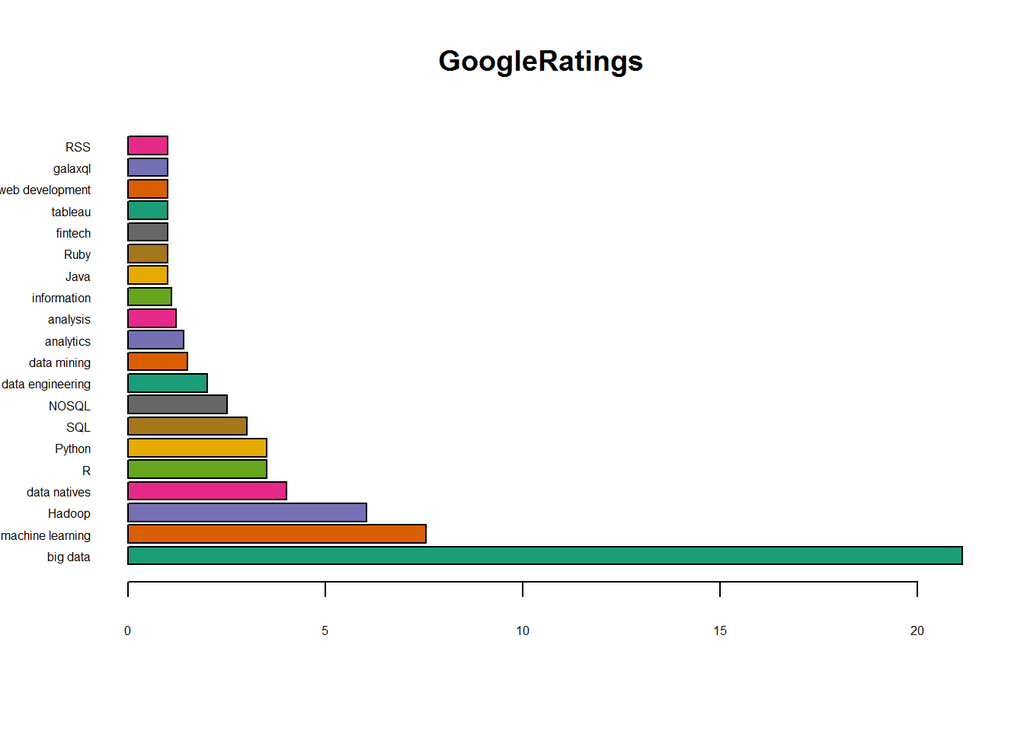

```r
darkcols <- brewer.pal(8,"Dark2")
names <- Combined$GoogleSkills
barplot(Combined$GoogleRatings,main="GoogleRatings", horiz=TRUE, names.arg=names, las=1, col=darkcols, cex.axis=0.5, cex.names = 0.5)
```

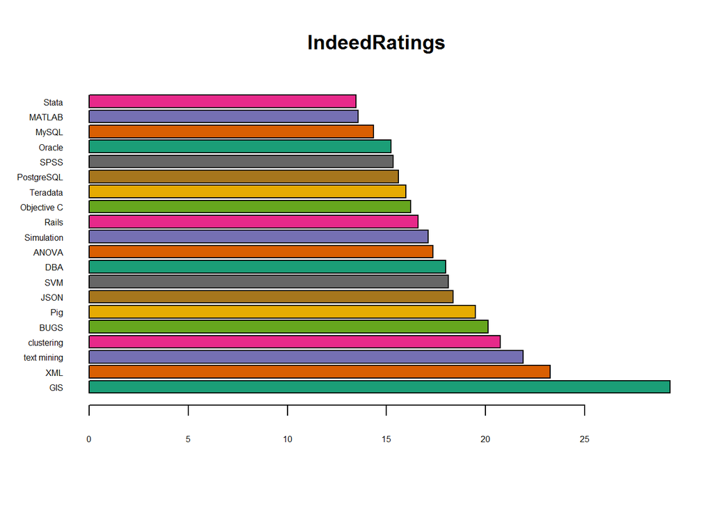

```r
names <- Combined$IndeedSkills
barplot(Combined$IndeedRatings,main="IndeedRatings", horiz=TRUE, names.arg=names, las=1, col=darkcols, cex.axis=0.5, cex.names = 0.5)
```

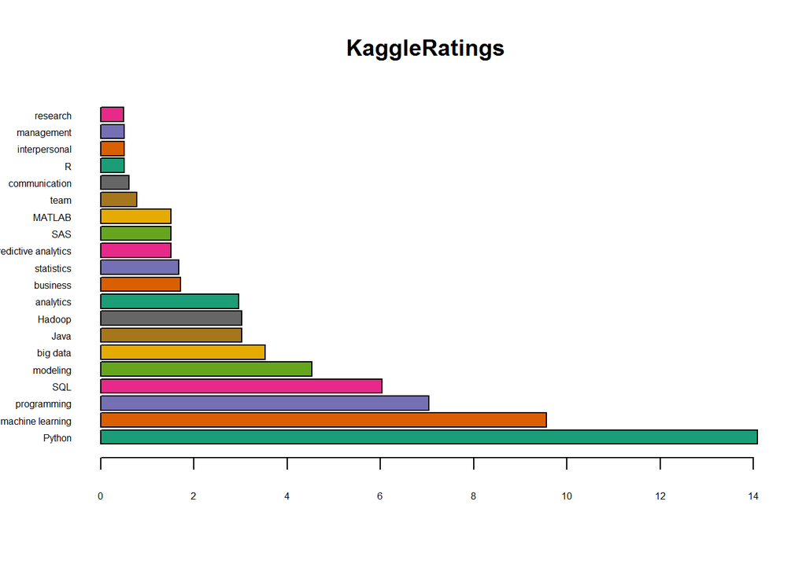

```r
names <- Combined$KaggleSkills
barplot(Combined$KaggleRatings,main="KaggleRatings", horiz=TRUE, names.arg=names, las=1, col=darkcols, cex.axis=0.5, cex.names = 0.5)
```

#### 3. Bubble Graph Showing Weighted Rank of Skills by Skill Type and Source (Google, Indeed and Kaggle)

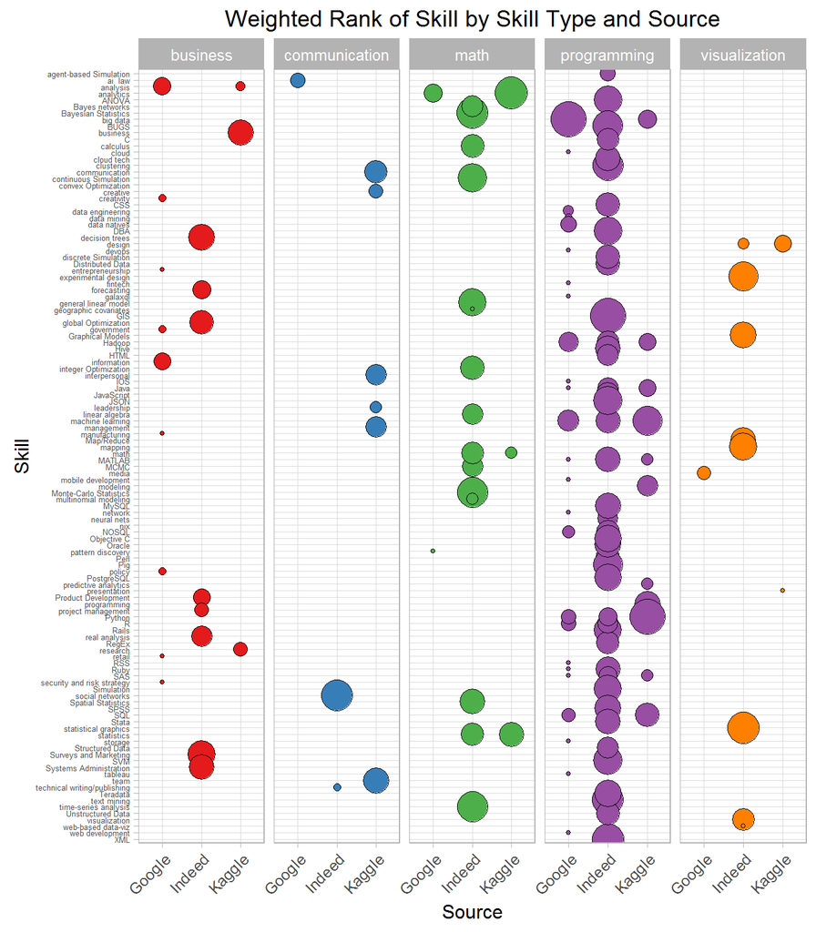

```r
data_science <- jobdata

data_science$skill_name <- factor(data_science$skill_name)
data_science$skill_name <- factor(data_science$skill_name, levels = rev(levels(data_science$skill_name)))

ggplot(data_science[(data_science$source_id != 2),],
       aes( source_name, skill_name, label = skill_name,
           size = rating_scalar, fill = skill_type_name)) +
        geom_point(pch = 21) +
        scale_fill_manual(values =  brewer.pal(9, "Set1")) +
        scale_size_continuous(range =c(1,10)) +
        facet_grid(~skill_type_name) +
        theme_light() +
        xlab("Source") +
        ylab("Skill") +
        theme(legend.position = "none" ,
              axis.text.y = element_text(size=5),
              axis.text.x = element_text(angle = 45, hjust = 1)) +
        ggtitle("Weighted Rank of Skill by Skill Type and Source")
```

```r
stab <- data %>%
        group_by(source_name,skill_type_name) %>%
        summarise(ave_wgt =mean(weighted_rating_overall))

ggplot(stab, aes(x =source_name, y=round(ave_wgt,2), fill = skill_type_name)) +
       geom_bar(stat="identity",position="dodge") +
       xlab("Source") +
       ylab("Average Weighted Rating Overall") +
       ggtitle("Average Weighted Overall Rating by Source and Skill Type")
```

[output not shown]

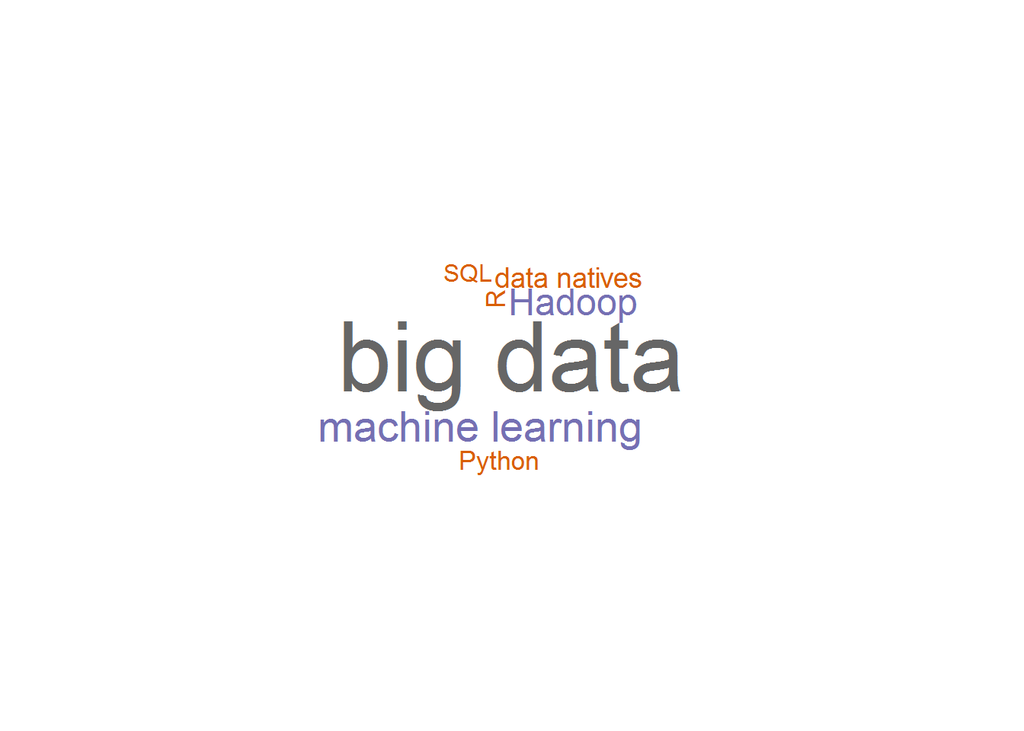

```r
require(wordcloud)

google <- subset(jobdata, source_name=="Google")
indeed <- subset(jobdata, source_name=="Indeed")
kaggle <- subset(jobdata, source_name=="Kaggle")

wordcloud(google$skill_name, google$weighted_rating_overall, random.order = FALSE, colors=brewer.pal(8, "Dark2"))
```

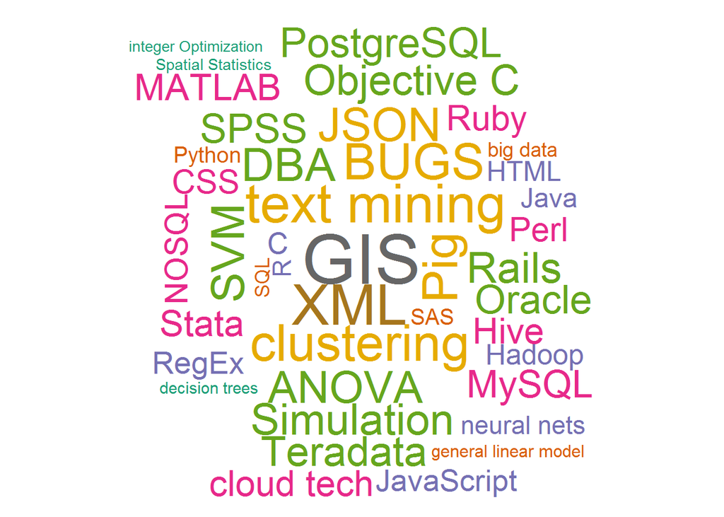

```r
wordcloud(indeed$skill_name, indeed$weighted_rating_overall, random.order = FALSE, colors=brewer.pal(8, "Dark2"))
```

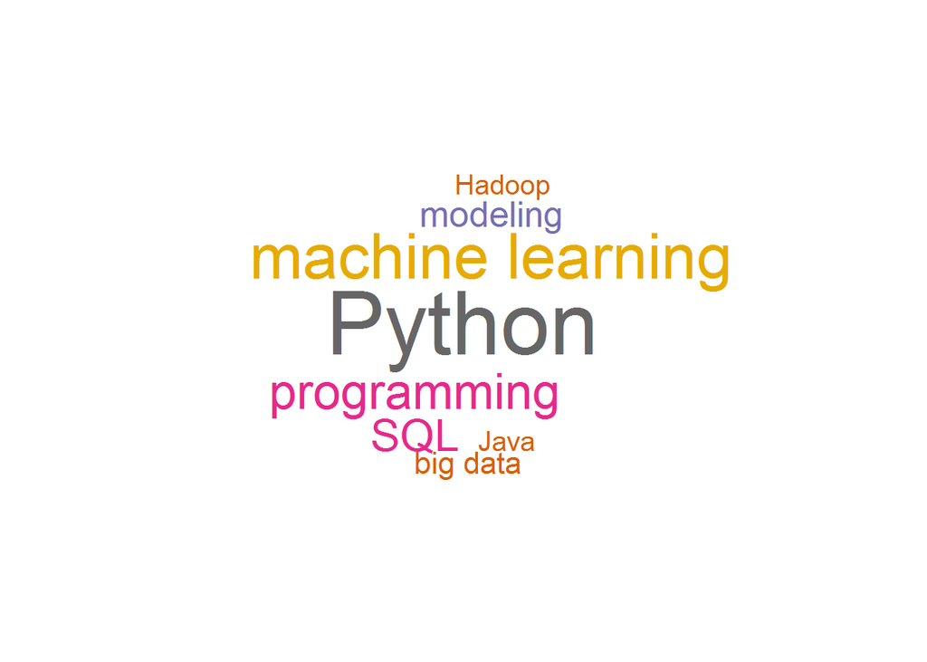

```r
wordcloud(kaggle$skill_name, kaggle$weighted_rating_overall, random.order = FALSE, colors=brewer.pal(8, "Dark2"))
```